# Week 3: Lab - Visualization

Victor Arencibia

1/29/2022

# Instructions

In Chapter 12, we explored many different ways to “look at” the numbers. For this lab, let’s explore the `mtcars` dataset that is included within R.

This activity description does not provide the same level of code prompts as previous labs – it is assumed that you remember or can look up the necessary code. The overall goal of this activity is to use `ggplot2` to show different attributes of the `mtcars` dataset. Please be sure to include both the code and the images that were generated with your assignment.

Add all of your libraries that you use for this assignment here.

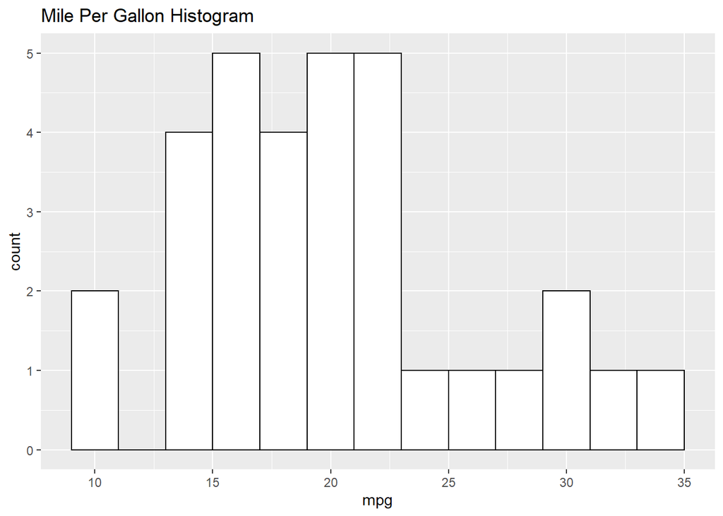

```r
EnsurePackage <- function(x) {
x <- as.character(x)
if (!require(x,character.only=TRUE)) {
  install.packages(pkgs=x, repos="https://cran.r-project.org")
  require(x,character.only=TRUE)
  }
}

EnsurePackage("ggplot2")
# Generate the following visualizations:

## Step 1 - Histogram

#Histogram of `mpg`

#{r, "Step 1"}
# Write your code below.
g <- ggplot(mtcars, aes(x=mpg))
g <- g + geom_histogram(binwidth=2,color="black", fill="white")
g <- g + ggtitle("Mile Per Gallon Histogram")
g
```

## Step 2 - Boxplots

Boxplots of `mpg` by `cyl` (i.e. 3 box plots: one for all cars with 4 cylinders, one for all cars with 6 cylinders, and one with all the cars with 8 cylinders).

```r
# Write your code below.

df <- mtcars
df$cyl <- as.factor(df$cyl)
head(df)
```

```
##                    mpg cyl disp  hp drat    wt  qsec vs am gear carb
## Mazda RX4         21.0   6  160 110 3.90 2.620 16.46  0  1    4    4
## Mazda RX4 Wag     21.0   6  160 110 3.90 2.875 17.02  0  1    4    4
## Datsun 710        22.8   4  108  93 3.85 2.320 18.61  1  1    4    1
## Hornet 4 Drive    21.4   6  258 110 3.08 3.215 19.44  1  0    3    1
## Hornet Sportabout 18.7   8  360 175 3.15 3.440 17.02  0  0    3    2
## Valiant           18.1   6  225 105 2.76 3.460 20.22  1  0    3    1
```

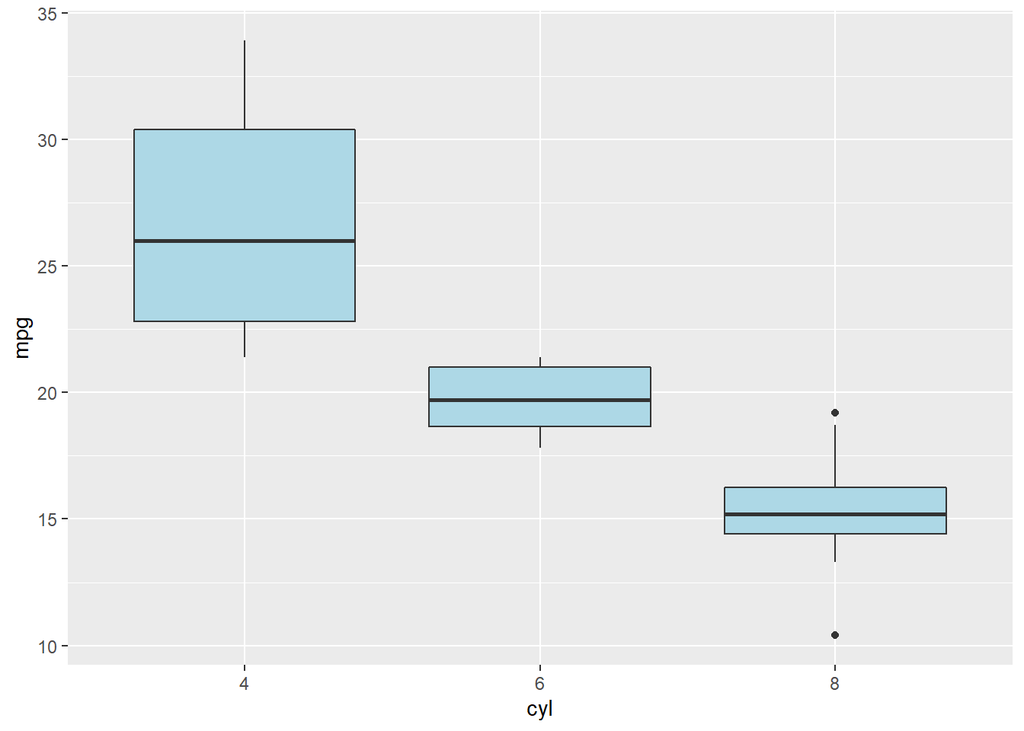

```r
ggplot(df, aes(x=cyl, y=mpg)) + geom_boxplot() + geom_boxplot(fill = "lightblue")
```

## Step 3 - MultiLine chart

MultiLine chart of `wt` on the x-axis, `mpg` for the y-axis. With a line for each `am` (i.e. two lines). Also be sure to show each point on the chart.

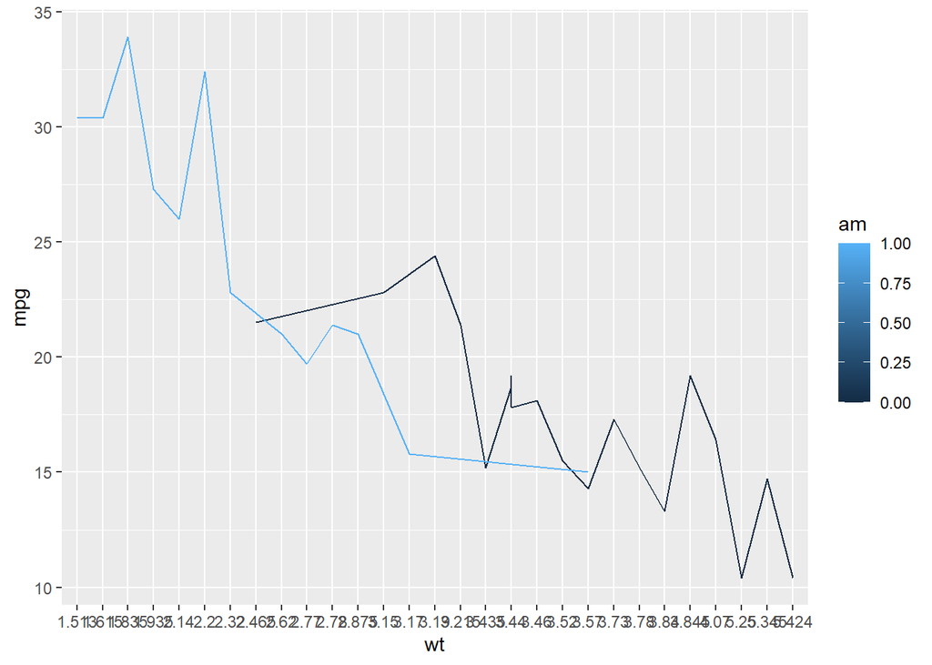

```r
# Write your code below.
df$wt <- as.factor(df$wt)
ggplot(df, aes(x=wt, y=mpg, group=am)) + geom_line(aes(color=am))
```

## Step 4 - Barchart

Barchart with the x-axis being the name of each car, and the height being `wt`. Make sure to rotate the x-axis labels, so we can actually read the car name.

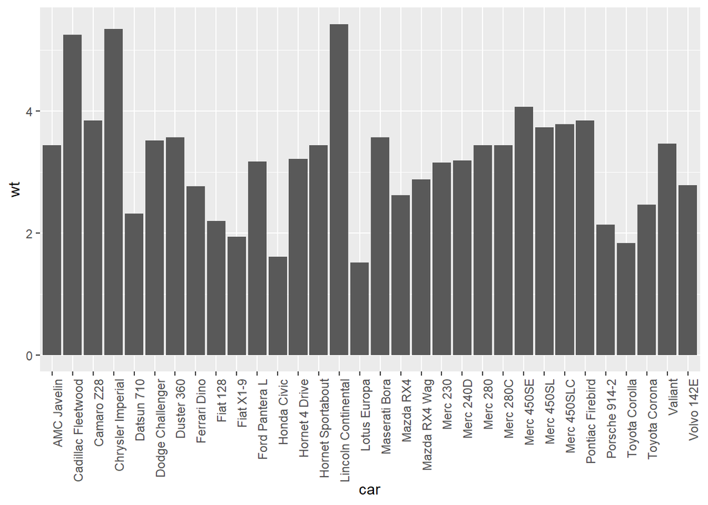

```r
# Write your code below.
df <- mtcars
df[["car"]] <- rownames(df)

bc <- ggplot(df, aes(x=car, y=wt))+ geom_bar(stat="identity")
bc <- bc + theme(axis.text.x = element_text(angle = 90, hjust = 1))
bc
```

## Step 5 - Scatter chart

Scatter chart with the x-axis being the `mpg` and the y-axis being the `wt` of the car. Have the color and the size of each “symbol” (i.e., circle) represent how fast the car goes (based on the `qsec` attribute).

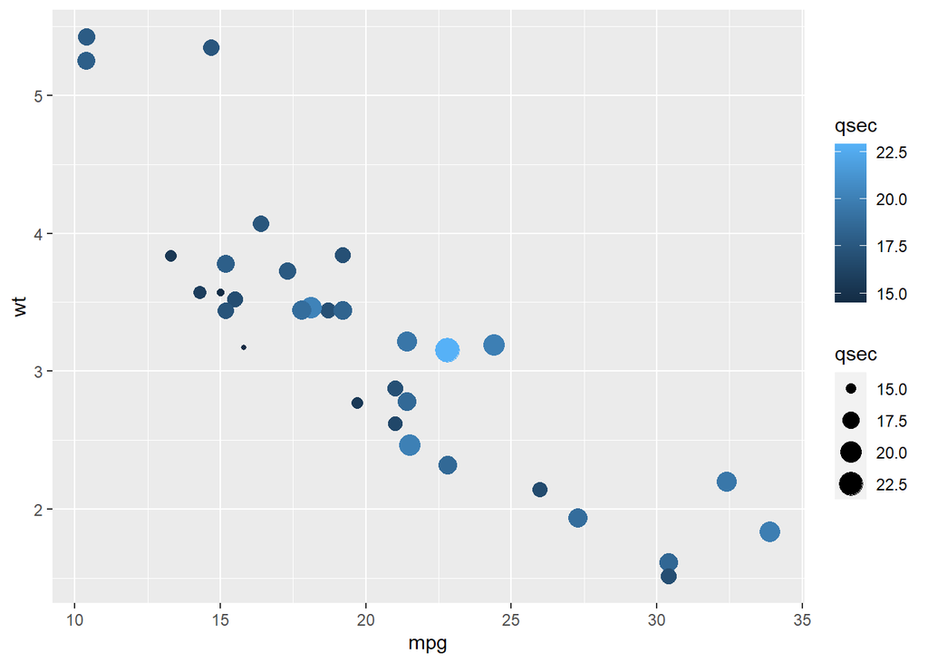

```r
# Write your code below.

z <- ggplot(df, aes(x=mpg, y=wt))
z <- z + geom_point(aes(size=qsec, color=qsec))
z
```